# Clonotrace

```r
library(Seurat)
library(dplyr)
library(ggplot2)
library(Matrix)
library(future)
library(future.apply)
```

```r
library(Clonotrace)
```

## Introduction

Understanding clonal structure and dynamics is a central problem in single-cell transcriptomics, particularly in immune and cancer biology. Modern single-cell technologies increasingly enable joint measurement of transcriptomes and clonal barcodes (e.g., TCR sequences or genetic lineage tracers), providing an opportunity to study how transcriptional states evolve at the clone level rather than at the level of individual cells.

**Clonotrace** is designed to analyze clonal behavior in single-cell data by integrating transcriptomic embeddings with clone information. Rather than treating clones as discrete labels, Clonotrace models each clone as a distribution of cells in a low-dimensional embedding space, enabling quantitative comparison of clonal transcriptional states.

This vignette provides a step-by-step tutorial demonstrating how to use Clonotrace to: - Estimate clone-level density in a cell embedding - Compute clone-to-clone distances using optimal transport (OT) - Cluster clones into transcriptional profiles - Perform downstream analyses such as profile-level pseudotime and gene association

## Installation

Clonotrace can be installed from GitHub:

```r
install.packages("devtools")
devtools::install_github("yuntianf/Clonotrace")
```

### data

Clonotrace requires two main inputs:

A low-dimensional cell embedding, typically derived from PCA, or other dimensionality reduction methods applied to gene expression data.

A cell-by-clone identity matrix, which is a binary matrix to indicate if a given cell belongs to a given clone.

Throughout this vignette, we assume that the embedding has already been computed and that clone identity are available (e.g., from TCR sequence or lineage barcodes).

We begin by loading an example dataset. The example data is from a public in vitro longitudinal experiment to monitor the hematopoiesis (https://www.science.org/doi/10.1126/science.aaw3381). You can download the demo data from: https://upenn.box.com/s/x099vybef0qop0cljbuan89x5jqvgnwx

The full dataset is intentionally not bundled with the package. To rerun this tutorial, set the `CLONOTRACE_DEMO_DATA` environment variable to the downloaded RDS file. When that file is unavailable during package-site construction, the code remains visible and the vignette displays the validated figures from the published analysis.

```r
seurat_object = readRDS(demo_data_path)
```

```r
pca = seurat_object@reductions$pca@cell.embeddings
umap = as.data.frame(seurat_object@reductions$umap@cell.embeddings)
cell_meta = seurat_object@meta.data
```

Within this data, there are 34782 cells are sampled at 3 time points.

```r
table(cell_meta$Time.point)
```

This data has a simple cell type composition with only 3 cell types:

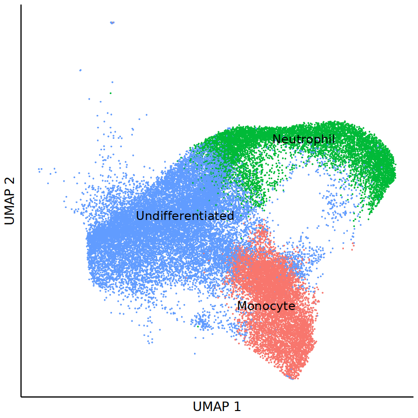

```r
cell_type_umap = dimplot(embedding = umap,annot = cell_meta,color_by = "Cell.type.annotation",size = 0.1,label_size = 5)+
NoLegend()+
theme(axis.text = element_blank(),
      axis.ticks = element_blank())+
xlab("UMAP 1")+ylab("UMAP 2")
cell_type_umap
```

For a higher resolution in the downstream analysis, we further cluster cells into 9 cell clusters.

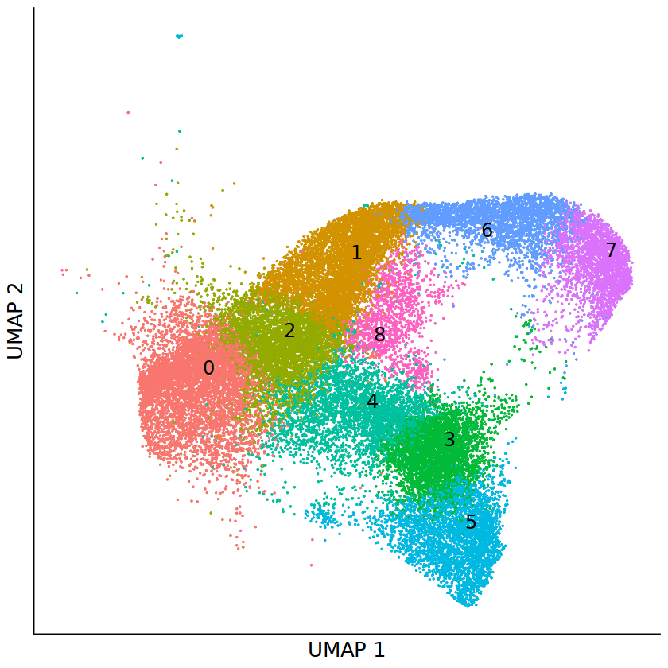

```r
cell_cluster_umap = dimplot(embedding = umap,annot = cell_meta,color_by = "cluster",size = 0.1,label_size = 5)+
NoLegend()+
theme(axis.text = element_blank(),
      axis.ticks = element_blank())+
xlab("UMAP 1")+ylab("UMAP 2")
cell_cluster_umap
```

### clone label spreading

We first build a cell kNN graph based on the PCA space:

```r
cell_knn = embedding2knn(embedding = as.matrix(pca),k = 30,mode = "connectivity",if_self = FALSE)
cell_knn = compute_transition(cell_knn)
```

Here we define a clone as a population of cells which share the same lineage barcode at the same time point. Based on this definition there are 8108 clones in total. 802 out of them expanded over 10 cells.

```r
clone_size = cell_meta %>% group_by(clone) %>% summarise(count = n())
expanded_clones = clone_size %>% filter(count >=10)
```

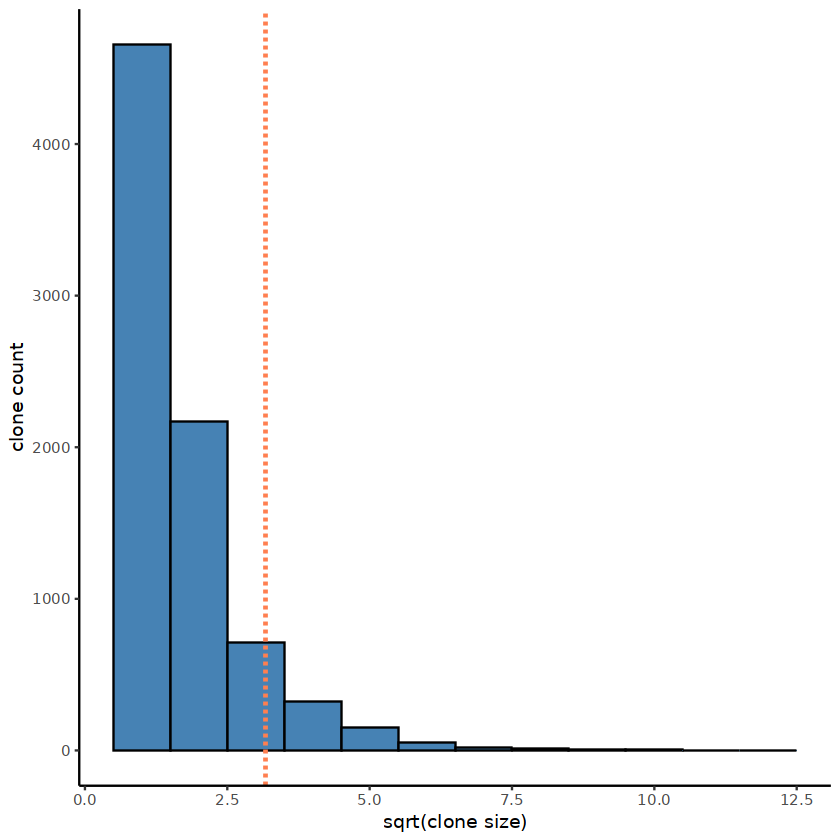

```r
clone_size_hist = ggplot(clone_size)+
geom_histogram(aes(x = sqrt(count)),binwidth = 1,color = "black",fill = "steelblue")+
geom_vline(xintercept = sqrt(10),linetype = "dashed",color = "coral",linewidth = 1)+
theme_classic()+
xlab("sqrt(clone size)")+
ylab("clone count")
clone_size_hist
```

Then we could spread the clone label in the cell graph to smooth the cell density in those expanding clones. There is a bootstrap during this process to filter out propagations with high deviance, usually in regions with high density of lowly expanded or non-expanded clones. So it’s better to run this in parallel.

```r
cell_clone = data.frame(cell = rownames(cell_meta),clone = cell_meta[,"clone"]) %>%
            mutate(clone = if_else(clone %in% expanded_clones$clone, clone, NA_character_))
```

```r
start = Sys.time()
plan(multisession,workers = 2)
clone_labels = label_spreading_bootstrap(adj = cell_knn,labels = cell_clone$clone,
                                         alpha = 0.6, sample_rate = 0.8,
                                         sample_n = 48, backend = "blocked",
                                         block_size = 128)
end = Sys.time()
print(end-start)
```

There are two main outputs from this step, the first one is the propagated clone labels for each cell and the second one is the deviance of each propagated label.

```r
cell_clone_prob_raw = clone_labels[[1]]
deviance = clone_labels[[2]]
```

```r
rownames(cell_clone_prob_raw) = rownames(cell_meta)
```

We can first show the distribution of the deviance in a histogram:

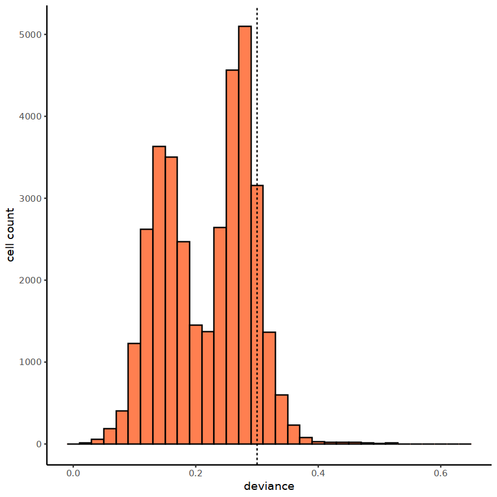

```r
deviance_hist = ggplot()+
geom_histogram(aes(x = deviance),fill = "coral",color = "black",binwidth = 0.02)+
geom_vline(xintercept = 0.3,linetype = "dashed")+
theme_classic()+
ylab("cell count")
deviance_hist
```

We can visualize the deviance of clone label spreading in each cell via cell UMAP, and here we use the 0.3 as the upper bound threshold for deviance. Cells with high deviance are enriched in undifferentiated cells.

```r
cell_meta$deviance = deviance
```

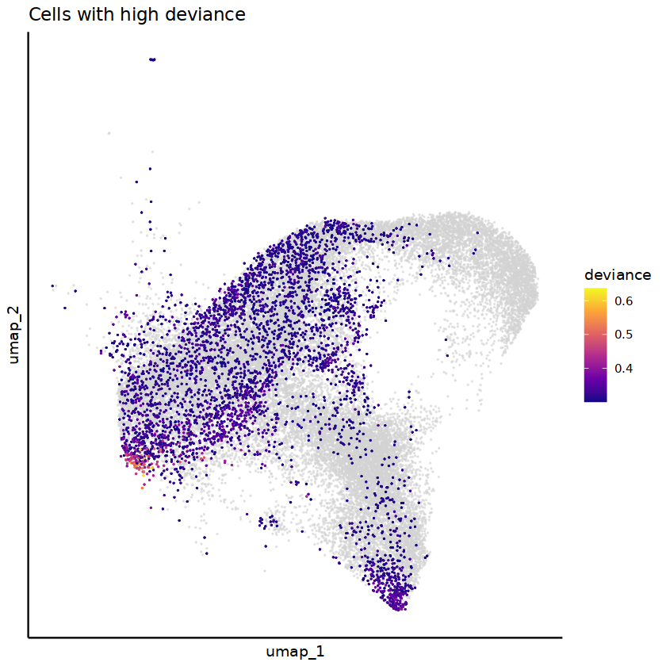

```r
deviance_umap = dimplot(umap,annot = cell_meta %>% filter(deviance > 0.3),color_by = "deviance",label = FALSE,size = 0.1)+
scale_color_viridis_c(name = "deviance",option = "plasma")+
theme_classic()+
theme(axis.text = element_blank(),
      axis.ticks = element_blank())+
ggtitle("Cells with high deviance")
deviance_umap
```

Then we filter out cells with high deviance, and sparsify the cell-to-clone probability by keeping top 90% mass

```r
rownames(cell_clone_prob_raw) = rownames(cell_meta)
```

```r
cell_clone_prob = cell_clone_prob_raw[deviance < 0.3,]
cell_clone_prob = cell_clone_prob/rowSums(cell_clone_prob)
```

```r
cell_clone_prob = mat_sparsify(mat = cell_clone_prob,row_mass = 0.9,col_mass = 0.9)
cell_clone_prob = cell_clone_prob/rowSums(cell_clone_prob)
cell_clone_prob = Matrix(cell_clone_prob, sparse = TRUE)
```

```r
colnames(cell_clone_prob) = names(table(cell_clone$clone))
```

#### Safe stopping point after label propagation

The sparse `cell_clone_prob` matrix is the reusable output of label propagation. It can be saved in the language-independent Matrix Market format, with separate tab-delimited files preserving the cell and clone identifiers:

```r
dir.create("clonotrace_intermediate", showWarnings = FALSE)

Matrix::writeMM(
  cell_clone_prob,
  "clonotrace_intermediate/cell_clone_prob.mtx"
)
write.table(
  data.frame(cell = rownames(cell_clone_prob)),
  "clonotrace_intermediate/cell_clone_prob_cells.tsv",
  sep = "\t", quote = FALSE, row.names = FALSE
)
write.table(
  data.frame(clone = colnames(cell_clone_prob)),
  "clonotrace_intermediate/cell_clone_prob_clones.tsv",
  sep = "\t", quote = FALSE, row.names = FALSE
)
```

The analysis can later resume from these files without repeating label propagation:

```r
cell_clone_prob = Matrix::readMM(
  "clonotrace_intermediate/cell_clone_prob.mtx"
)
cell_ids = read.delim(
  "clonotrace_intermediate/cell_clone_prob_cells.tsv",
  stringsAsFactors = FALSE
)$cell
clone_ids = read.delim(
  "clonotrace_intermediate/cell_clone_prob_clones.tsv",
  stringsAsFactors = FALSE
)$clone

dimnames(cell_clone_prob) = list(cell_ids, clone_ids)
cell_clone_prob = methods::as(cell_clone_prob, "CsparseMatrix")
```

We can use an example to show how the cell clone assignment is smoothed during this process:

```r
example_clone = "Lineage-1193-6"
```

First we show the raw cell distribution of the example clone:

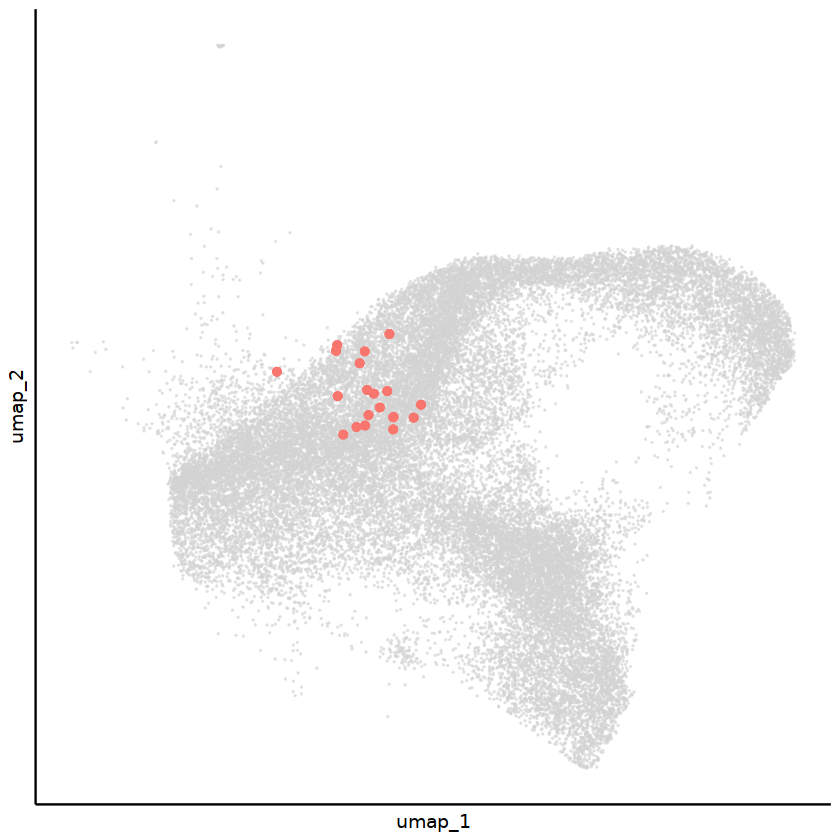

```r
clone_example_umap_raw = dimplot(umap,annot = cell_meta %>% filter(clone == example_clone) %>% mutate(group = "1"),
                                 color_by = "group",label = FALSE,size = 2)+
theme_classic()+
NoLegend()+
theme(axis.text = element_blank(),
      axis.ticks = element_blank())

clone_example_umap_raw
```

And after label propagation, its cell distribution becomes more continous.

```r
cell_meta$prob = NA
cell_meta[rownames(cell_clone_prob),]$prob = cell_clone_prob[,example_clone]
```

```r
umap$prob = cell_meta$prob
```

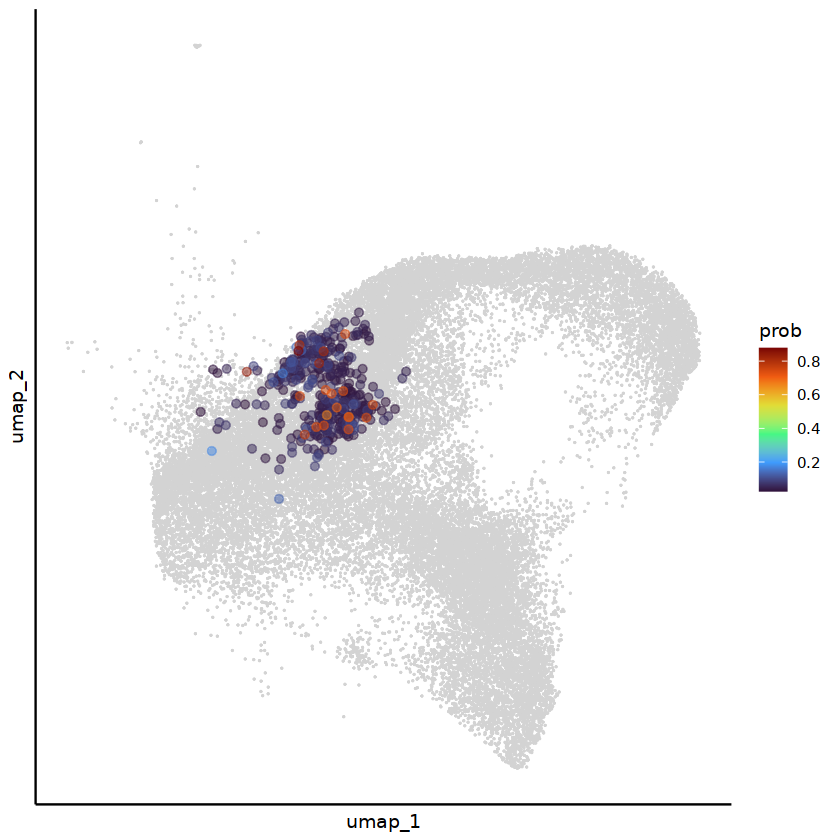

```r
clone_example_umap_smooth = ggplot(mapping = aes(x= umap_1,y = umap_2))+
geom_point(data = umap,color = "lightgrey",size = 0.1)+
geom_point(data = umap %>% filter(prob > 0.025) %>% arrange(prob),
           aes(color = prob),size = 2,alpha = 0.5)+
scale_color_viridis_c(name = "prob",option = "turbo")+
theme_classic()+
theme(axis.text = element_blank(),
      axis.ticks = element_blank())
clone_example_umap_smooth = ggrastr::rasterize(clone_example_umap_smooth,layers='Point', dpi=300)
clone_example_umap_smooth
```

### Clonewise transcriptomic distance

After we smooth the cell density for each expanded clone over the cell transcriptomic embedding, we can measure their cell distributional difference via optimal transportation distance.

We provide two methods for this: exact optimal transport and a faster nearest-neighbor approximation. In Clonotrace 1.2.1, exact OT uses a disk-backed, checkpointed implementation by default, which reduces peak memory without changing the distance definition. The published Figure 4 analysis used the original unadjusted distance, so `revised = FALSE` is specified explicitly below.

```r
# not run
plan(multisession, workers = 2)
### exact OT distance
clone_dis = clone_disance(
  as.matrix(pca), cell_clone_prob, outpath = "./",
  exact = TRUE, exact_backend = "disk", force_exact = TRUE,
  revised = FALSE, cores = 2, distance_block_size = 256,
  target_cell_limit = 5000,
  checkpoint_dir = "./exact_ot_checkpoints"
)
### nearest neighbor distance approximation
clone_dis = clone_disance(
  as.matrix(pca), cell_clone_prob, outpath = "./",
  exact = FALSE, revised = FALSE
)
```

This step can still take hours on a large dataset. The exact calculation writes the cell-distance store and completed clone pairs to disk, so an interrupted run can resume from the same output and checkpoint directories. Increase the number of workers only after confirming that sufficient memory remains available.

`clone_disance()` creates or reuses the following intermediate files in `outpath`:

- `cell_graph.rds` stores the validated cell graph used by both clone-distance methods.
- `clone_graph_dis.rds` stores the completed approximate clone distances generated with `exact = FALSE`.
- `clone_graph_dis_exact.rds` stores the completed exact-OT clone distances generated with `exact = TRUE`.

Disk-backed exact OT also creates `cell_graph_distance_exact.bin` and its metadata sidecar, which store the cell-graph distances in restartable row blocks, together with validated per-source checkpoints in `exact_ot_checkpoints/`. Each cached object records the inputs and parameters used to generate it; Clonotrace reuses it only when these metadata match the current analysis. The obsolete `groups_graph_dis.rds` file is no longer generated.

#### Safe stopping point after clone-distance calculation

If exact OT is interrupted, rerun the same `clone_disance()` call with unchanged inputs and parameters. Clonotrace will validate and reuse the completed internal checkpoints automatically. After either distance method finishes, the returned long-format clone-pair table can also be exported as a compressed, portable tab-delimited file:

```r
dir.create("clonotrace_intermediate", showWarnings = FALSE)
distance_file = "clonotrace_intermediate/clone_distance.tsv.gz"
connection = gzfile(distance_file, open = "wt")
write.table(
  clone_dis, connection,
  sep = "\t", quote = FALSE, row.names = FALSE
)
close(connection)
```

Reload this table to continue with clone embedding and downstream analyses:

```r
connection = gzfile(
  "clonotrace_intermediate/clone_distance.tsv.gz",
  open = "rt"
)
clone_dis = read.delim(connection, stringsAsFactors = FALSE)
close(connection)
```

The `.rds` and binary files listed above are package-managed restart caches rather than portable exchange files; users should retain them when they want automatic checkpoint reuse and use the Matrix Market or compressed TSV exports when sharing intermediate results across software environments.

Here for time efficiency, we can use the pre-computed clone-wise distance for downstream applications.

```r
file_path <- system.file("extdata", "clone_graph_dis.tsv", package = "Clonotrace")
clone_dis = read.table(file_path,sep = "\t")

clone_dis = long2square(long = as.data.frame(clone_dis),row_names_from = "group1",
                        col_names_from = "group2",values_from = "dis",symmetric = T)
diag(clone_dis) = 0
rownames(clone_dis) = colnames(clone_dis) = colnames(cell_clone_prob)
```

### clone embedding visualization

We first cluster clones using leiden algorithm and visualize the clone community in the UMAP.

```r
set.seed(1230)
clone_cluster = leiden_dis(dismat = clone_dis,k = 20,resolution = 0.5,if_umap = TRUE)
clone_cluster_center = clone_cluster %>% group_by(cluster) %>% summarise_all(median)
```

```r
clone_cluster$mass = colSums(cell_clone_prob)
```

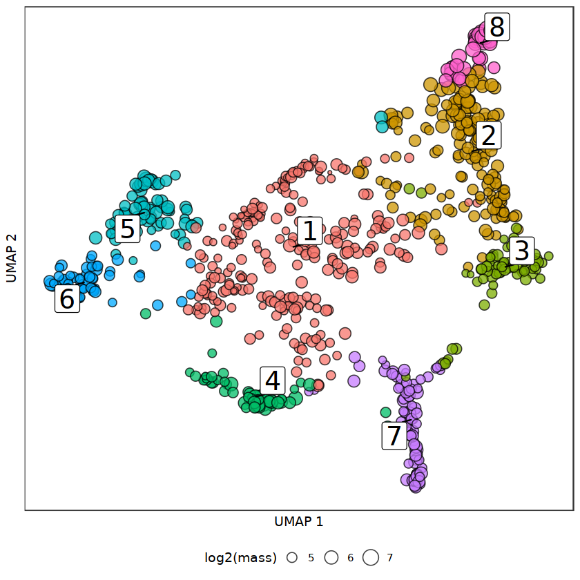

```r
clone_leiden_umap = ggplot(mapping = aes(x = umap1,y = umap2))+
geom_point(data = clone_cluster,aes(fill = cluster,size = log2(mass)),pch=21,color = "black",alpha = 0.75)+
ggrepel::geom_label_repel(data = clone_cluster_center,aes(label = cluster),size = 8)+
theme_bw()+
theme(axis.text = element_blank(),
      axis.ticks = element_blank(),
      panel.grid.major = element_blank(),
      panel.grid.minor = element_blank())+
guides(fill = guide_legend(override.aes = list(size=5)))+
guides(fill = "none")+
theme(legend.position = "bottom")+
xlab("UMAP 1")+ylab("UMAP 2")
clone_leiden_umap
```

We can also visualize the clone embedding in other low dimension reductions like a diffusion map:

```r
clone_leiden_dm <- diffusionMap::diffuse(clone_dis,maxdim = 30)
clone_leiden_dm_coord = as.data.frame(clone_leiden_dm$X)
colnames(clone_leiden_dm_coord) = paste("dm",1:ncol(clone_leiden_dm_coord),sep = "")
rownames(clone_leiden_dm_coord) = rownames(clone_cluster)
```

```r
dm_cluster_center = clone_leiden_dm_coord %>% group_by(clone_cluster$cluster) %>% summarise_all(median)
colnames(dm_cluster_center)[1] = "cluster"
```

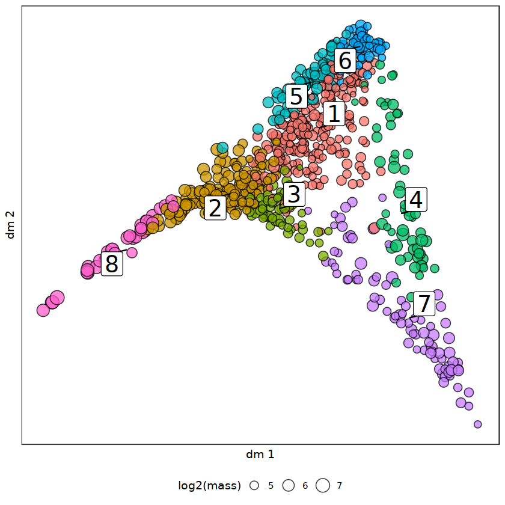

```r
clone_leiden_diffmap = ggplot(mapping = aes(x = dm1,y = dm2))+
geom_point(data = clone_leiden_dm_coord,aes(fill = clone_cluster$cluster,size = log2(clone_cluster$mass)),
           pch=21,color = "black",alpha = 0.75)+
ggrepel::geom_label_repel(data = dm_cluster_center,aes(label = cluster),size = 8)+
theme_bw()+
theme(axis.text = element_blank(),    # Remove axis numbers (labels)
      axis.ticks = element_blank(),
      panel.grid.major = element_blank(),
      panel.grid.minor = element_blank())+
guides(fill = "none",size = guide_legend(title = "log2(mass)"))+
theme(legend.position = "bottom")+
xlab("dm 1")+ylab("dm 2")
clone_leiden_diffmap
```

Diffusion map is good to layout continuous movement of clones over time. Here we can mark how clones with the same lineage barcodes change across time.

```r
clone_cluster = clone_cluster %>% mutate(clone = rownames(clone_cluster)) %>%
                                  mutate(lineage = substr(clone,start = 1,stop = nchar(clone)-2),
                                  time = substr(clone,start = nchar(clone),stop = nchar(clone))) %>%
                                  mutate(time = paste("day",time,sep = ""))
```

```r
clone_link = long2wide(clone_cluster %>% dplyr::select(lineage,time,clone),
                       row_names_from = "lineage",
                       col_names_from = "time",
                       values_from = "clone",
                       symmetric = FALSE)
clone_link = na.omit(clone_link)
```

```r
colnames(clone_link) = c("start","end")
```

```r
clone_link_coord = cbind(clone_link,
                         clone_leiden_dm_coord[clone_link$start,c("dm1","dm2")],
                         clone_leiden_dm_coord[clone_link$end,c("dm1","dm2")],
                         clone_cluster[clone_link$start,"cluster"],
                         clone_cluster[clone_link$end,"cluster"])
colnames(clone_link_coord) = c("start","end","xdm1","xdm2","ydm1","ydm2","x_cluster","y_cluster")
```

```r
sub_annot = clone_cluster %>% filter(lineage %in% rownames(clone_link_coord))
sub_dm_coord = clone_leiden_dm_coord[rownames(sub_annot),]
```

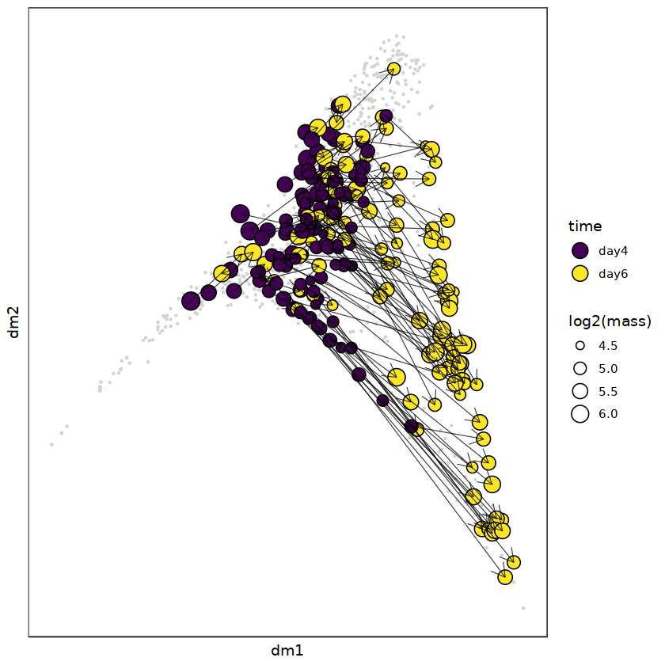

```r
clone_leiden_diffmap_arrow = ggplot()+
geom_point(data = clone_leiden_dm_coord,aes(x = dm1,y = dm2),size = 0.2,color = "lightgrey")+
geom_point(data = sub_dm_coord,aes(x = dm1,y = dm2,fill = sub_annot$time,size = log2(sub_annot$mass)),shape = 21)+
geom_segment(data = clone_link_coord,aes(x = xdm1,y = xdm2,xend = ydm1,yend = ydm2),
             arrow = arrow(length = unit(0.03, "npc")),linewidth = 0.25,alpha = 0.75)+
scale_fill_viridis_d(name = "time")+
theme_bw()+
theme(axis.text = element_blank(),    # Remove axis numbers (labels)
      axis.ticks = element_blank(),
      panel.grid.major = element_blank(),
      panel.grid.minor = element_blank())+
guides(fill = guide_legend(override.aes = list(size=5)),
       size = guide_legend(title = "log2(mass)"))
clone_leiden_diffmap_arrow
```

From the diffusion map we can see an organized clonal shift from day4 to day6.

### profile projection in cell embedding

After we cluster the clones into profiles, with the cell clone probability, we can also map cells to profiles:

```r
clone_profile = clone_cluster %>% dplyr::select(clone,cluster) %>% mutate(flag = 1)
clone_profile = long2sparse(long = clone_profile,row_names_from = "clone",col_names_from = "cluster",values_from = "flag")
```

```r
cell_profile_prob = cell_clone_prob %*% clone_profile[colnames(cell_clone_prob),]
rownames(cell_profile_prob) = rownames(cell_clone_prob)
```

For cells with profile probability higher than 0.5, we assign it with a profile label:

```r
cell_meta$profile = NA
cell_meta[rownames(cell_profile_prob),]$profile = apply(cell_profile_prob,1,function(x){
    if(max(x) > 0.5){
        return(which(x == max(x))[1])
    }
    else{
        return(NA)
    }
})
cell_meta = cell_meta %>% mutate(profile = as.factor(profile))
```

```r
cell_meta$profile_prob = NA
cell_meta[rownames(cell_profile_prob),]$profile_prob = apply(cell_profile_prob,1,max)
```

Then we can visualize how profile flow over the cell embedding:

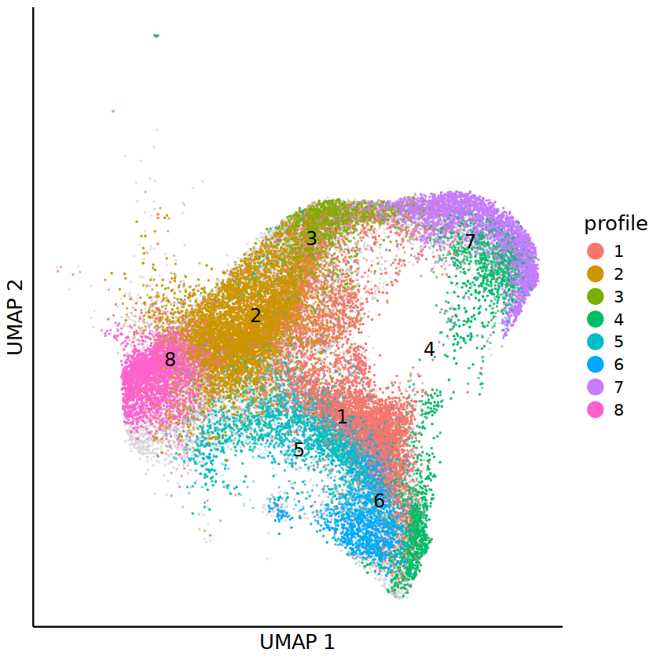

```r
cell_profile_umap = dimplot(embedding = umap,annot = cell_meta,color_by = "profile",
                            size = 0.1,alpha_by = "profile_prob",label = TRUE)+
theme(axis.text = element_blank(),
      axis.ticks = element_blank())+
xlab("UMAP 1")+ylab("UMAP 2")+
guides(alpha = "none",color = guide_legend(override.aes = list(size=5)))
cell_profile_umap
```

Obvisouly, profile 5 and 6 unipotently differentiate to monocytes and profile 3 and 7 unipotently differentiate to netriphil, while profile 1 and 4 denote the bipotent differenitation.

### Clone level pseudotime

We first generate the clone level pseudotime by diffusion pseudotime in the clone embedding. Here we use the clone distance projection in the MDS space as the clone embedding.

```r
clone_mds = MASS::isoMDS(as.matrix(clone_dis), k=30)
clone_embedding = clone_mds$points
colnames(clone_embedding) = paste("mds",1:ncol(clone_embedding),sep = "_")
rownames(clone_embedding) = rownames(clone_cluster)
```

This step is kind slow, here we also read a pre-computed MDS embedding for the downstream analysis:

```r
file_path <- system.file("extdata", "clone_mds.tsv", package = "Clonotrace")
clone_embedding = read.table(file_path,sep = "\t",header = TRUE)
```

Here we choose the cell cluster 0 as the starting cluster for diffusion pseudotime. The `clone_dpt` function would automatically choose the clone which has the highest enrichment in this starting cluster to be the root of diffusion pseudotime.

```r
clone_t = clone_dpt(clone_embedding = clone_embedding,cell_meta = cell_meta,
                    clone_col = "clone",cluster_col = "cluster",start_cluster = "0")
```

```r
clone_cluster$dpt = clone_t
```

We can then visualize the clone level pseudotime in the diffusion map:

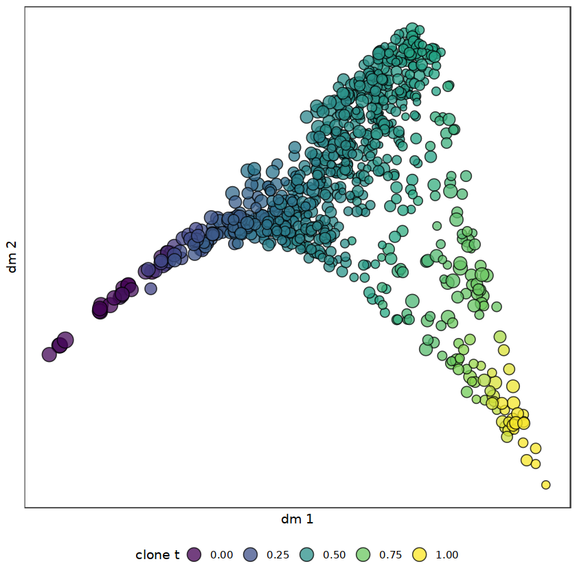

```r
clone_dpt_diffmap = ggplot(mapping = aes(x = dm1,y = dm2))+
geom_point(data = clone_leiden_dm_coord,aes(fill = clone_cluster$dpt,size = log2(clone_cluster$mass)),
           pch=21,color = "black",alpha = 0.75)+
theme_bw()+
theme(axis.text = element_blank(),    # Remove axis numbers (labels)
      axis.ticks = element_blank(),
      panel.grid.major = element_blank(),
      panel.grid.minor = element_blank())+
guides(fill = guide_legend(override.aes = list(size=5)))+
scale_fill_viridis_c(name = "clone t")+
guides(size = "none")+
theme(legend.position = "bottom")+
xlab("dm 1")+ylab("dm 2")
clone_dpt_diffmap
```

Then we can smooth the clone level pseudotime over the cell embedding by multiplying the clone pseudotime to cell clone probability. The pseudotime inference is necessary for the fate driving gene detection in the downstream analysis.

```r
cell_meta$cell_t = NA
cell_meta[rownames(cell_clone_prob),]$cell_t = cell_clone_prob[,clone_cluster$clone] %*% clone_cluster$dpt
```

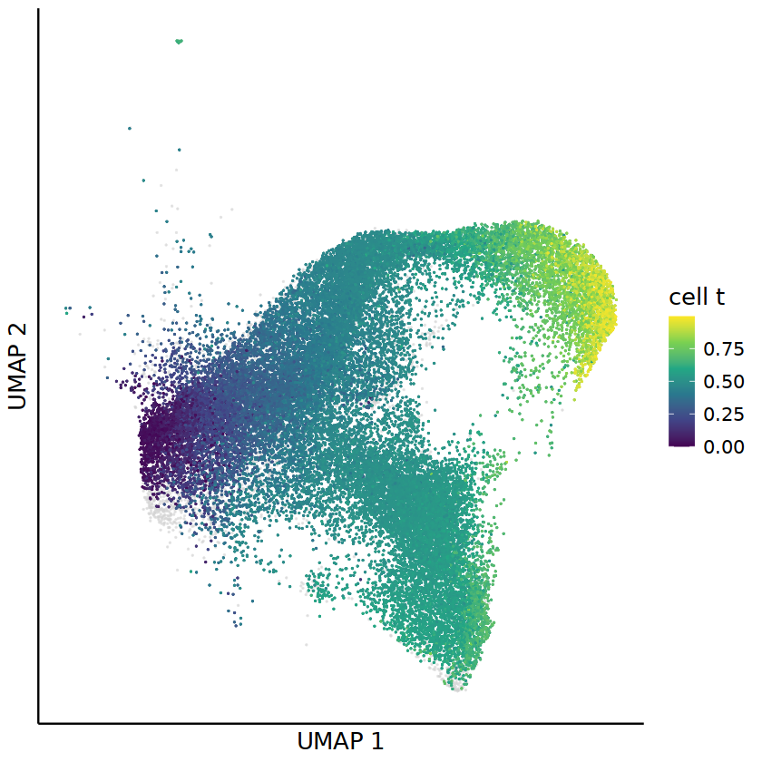

```r
cell_dpt_umap = dimplot(embedding = umap,annot = cell_meta,color_by = "cell_t",
                            size = 0.1,alpha_by = NULL,label = FALSE)+
theme(axis.text = element_blank(),
      axis.ticks = element_blank())+
xlab("UMAP 1")+ylab("UMAP 2")+
scale_color_viridis_c(name = "cell t")
cell_dpt_umap
```

### clone weighted cell embedding (optional)

By integrating information from both the clone embedding and the cell embedding, we developed a new visualization method called clone-weighted cell embedding. In this representation, even if two cells are close in the transcriptomic (cell) embedding, they will be pulled apart in the clone-weighted embedding if their corresponding clones are distant in clone space. This embedding can better illustrate the clone level heterogeneity.

```r
cell_k = 30
clone_k = 15
cell_embedding = pca[rownames(cell_clone_prob),]
```

```r
plan(multisession, workers = 2)
coembed_dis = cell_clone_coembed(
  cell_embedding, clone_embedding, cell_clone_prob,
  cell_k = cell_k, clone_k = clone_k
)
```

This function `cell_clone_coembed` would return a sparse distance matrix, which denotes a weighted kNN network between cells. We can project this kNN network to UMAP for visualization. This step requires a python script.

```r
# Optionally set RETICULATE_PYTHON before starting R.
library(reticulate)
python_path <- Sys.getenv("RETICULATE_PYTHON")
if (nzchar(python_path)) use_python(python_path, required = TRUE)
```

```r
script_path <- system.file("py", "embedding_from_kNN.py", package = "Clonotrace")
source_python(script_path)
```

```r
cell_coembed_umap = umap_from_knn(coembed_dis,n_neighbors = 10,seed = 512)
```

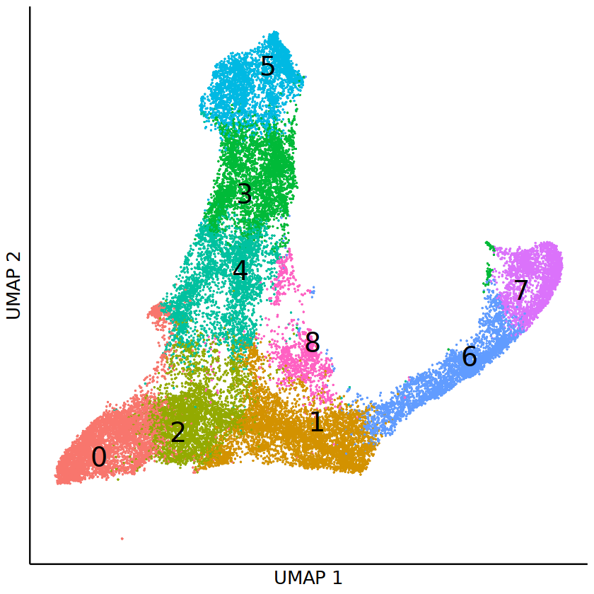

```r
coembed_umap_cluster = dimplot(embedding = cell_coembed_umap,annot = cell_meta,alpha_by = NULL,label_size = 8,
                          color_by = "cluster",size = 0.1,alpha = 1)+
theme(axis.text = element_blank(),    # Remove axis numbers (labels)
      axis.ticks = element_blank())+
xlab("UMAP 1")+ylab("UMAP 2")+
NoLegend()
coembed_umap_cluster
```

Obviously, there appear two boundaries within the two branches for monocytes (cluster 4, 3, 5) and neutriphils (cluster 1, 6, 7), which denote the clone level heterogeneity. Once we colored cells by the profile identity, we can see the two boundaries seperate the bipotent and unipotent profiles.

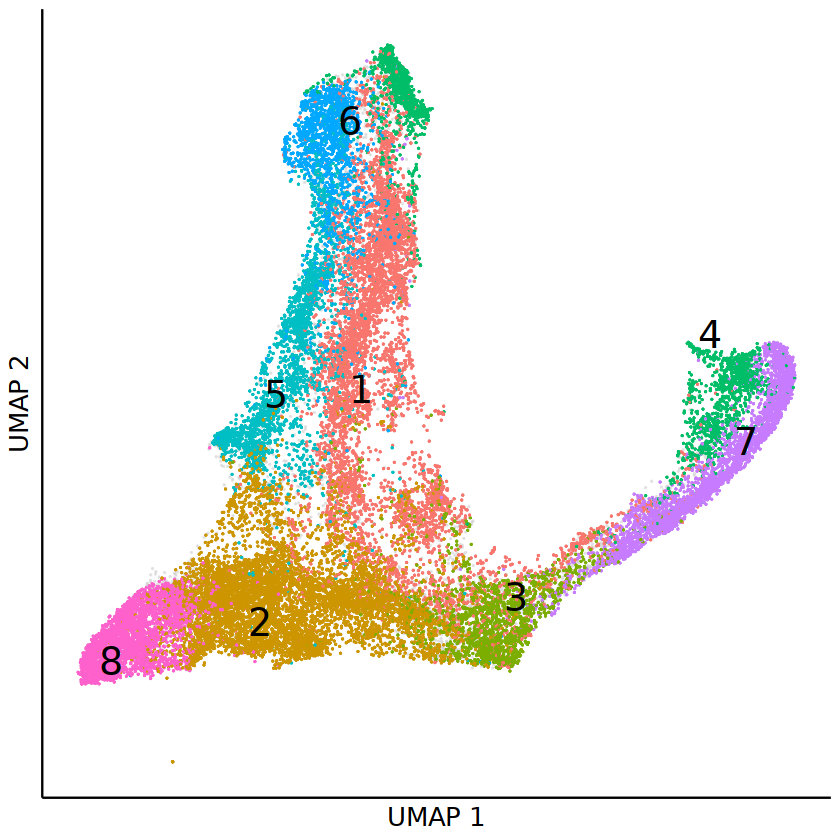

```r
coembed_umap_profile = dimplot(embedding = cell_coembed_umap,annot = cell_meta,alpha_by = NULL,label_size = 8,
                          color_by = "profile",size = 0.1,alpha = 1)+
theme(axis.text = element_blank(),    # Remove axis numbers (labels)
      axis.ticks = element_blank())+
xlab("UMAP 1")+ylab("UMAP 2")+
NoLegend()
coembed_umap_profile
```

### profile enrichment in each cluster

In the downstream analysis we will focus on the early bipotent profiles (profile) and detect early fate-associated genes. To achieve this goal we first do an enrichment test between profiles and clusters to show in which cluster profile 1 has significant high density. And then within the target cluster, we compare the gene expression between profile 1 and other profiles to identify early fate-associated genes.

We first do the cell cluster profile enrichment using permutation test:

```r
enrich = cluster_profile_enrich(cell_profile_prob,cell_meta[rownames(cell_profile_prob),"cluster"],permute_n  = 1000)
```

We can then visualize the enrichment result using a heatmap:

```r
mass_long = wide2long(enrich[[1]])
mass_long = mass_long %>% mutate(i = rownames(enrich[[1]])[i],
                                 j = colnames(enrich[[1]])[j])
colnames(mass_long) = c("cluster","profile","mass")
mass_long = mass_long %>% group_by(cluster) %>% mutate(freq = mass/sum(mass))
mass_long$pvalue = c(t(enrich[[2]]))
```

```r
mass_long$signif = "ns"
mass_long$signif[mass_long$pvalue< 0.05] = "*"
mass_long$signif[mass_long$pvalue< 0.01] = "**"
mass_long$signif[mass_long$pvalue< 0.001] = "***"
```

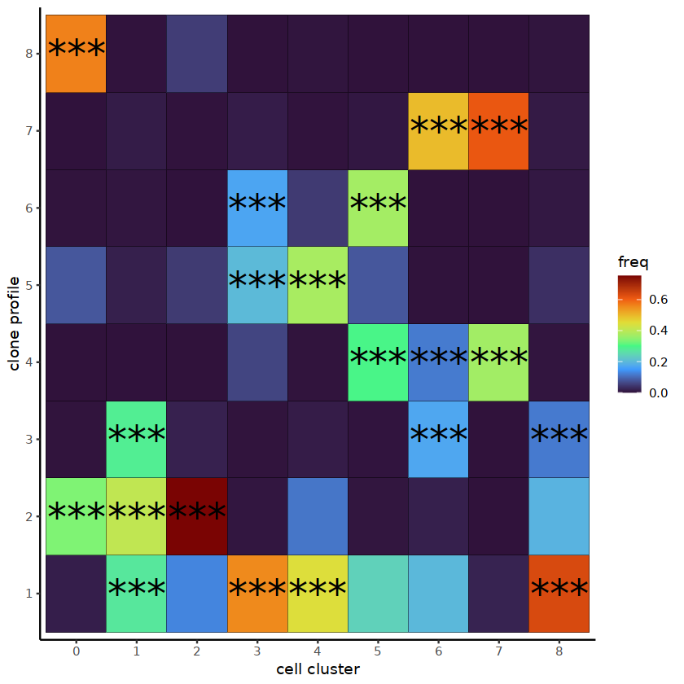

```r
cell_type_profile_enrich_heatmap = ggplot(mass_long,aes(x = cluster,y = profile))+
geom_tile(aes(fill = freq),color = "black")+
scale_fill_viridis_c(option = "turbo")+
geom_text(data = mass_long %>% filter(signif != "ns"),aes(label = signif),size = 10)+
theme_classic()+
xlab("cell cluster")+
ylab("clone profile")
cell_type_profile_enrich_heatmap
```

From the heatmap we can see that our target profile 1 is enriched in 4 cell clusters, including 1, 3, 4 and 8, within which cluster 1 and 4 are at early differentiation stage. Here, as an example, we will identify genes differentially expressed in profile 1 in cluster 4.

### profile DEG within clusters

```r
exprs = seurat_object@assays$RNA$data
```

```r
start = Sys.time()
DEG_1_4 = profile_cluster_DEG(profile = "1",cluster = "4",exprs = exprs,cell_meta = cell_meta,cell_profile_prob = cell_profile_prob)
end = Sys.time()
print(end - start)
```

```r
DEG_1_4_sig = DEG_1_4$stat %>% filter(padj < 0.05)
nrow(DEG_1_4_sig)
```

In total we identified 2165 genes which are differentially expressed in profile 1 in cluster 4.

Here we can take a look at the top 10 genes with the largest effect size.

```r
DEG_1_4_sig %>% top_n(abs(cohen),n = 10)
```

We can take `Dmkn` as an example to show how the linear regression model fits for the profile 1 and other profiles in cluster 4 along pseudotime:

```r
test_object = DEG_1_4
```

```r
null_fit = test_object$design_null %*% test_object$coef[3:4,]
full_fit = test_object$design_null %*% test_object$coef[1:2,]
rownames(null_fit) = rownames(full_fit) = test_object$cell
```

```r
example_gene = "Dmkn"
```

```r
cell_meta$exprs = exprs[example_gene,rownames(cell_meta)]
```

```r
cell_meta$null_exprs = NA
cell_meta[test_object$cell,]$null_exprs = null_fit[,example_gene]
cell_meta$full_exprs = NA
cell_meta[test_object$cell,]$full_exprs = full_fit[,example_gene]
```

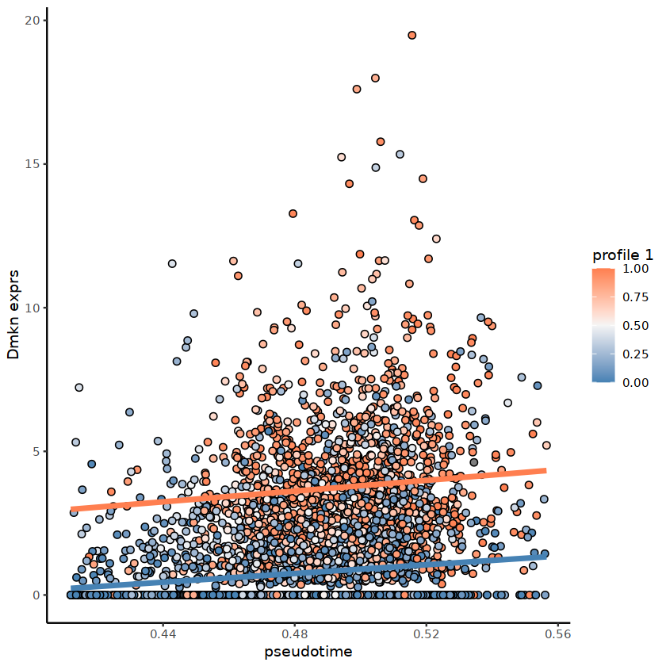

```r
gene_fit_cluster = ggplot(cell_meta[test_object$cell,])+
        geom_point(aes(x = cell_t,y = exprs,fill = cell_profile_prob[test_object$cell,"1"]),size = 2,shape = 21,color = "black")+
        geom_line(aes(x = cell_t,y = null_exprs),color = "steelblue",linewidth = 1.5)+
        geom_line(aes(x = cell_t,y = full_exprs),color = "coral",linewidth = 1.5)+
        scale_fill_gradient2(name = "profile 1",low = "steelblue",mid = "whitesmoke",high = "coral",midpoint = 0.5,limit = c(0,1))+
        theme_classic()+
        xlab("pseudotime")+ylab(paste(example_gene,"exprs",sep = " "))
gene_fit_cluster
```

We can further visualize the expression for `Dmkn` over the cell UMAP:

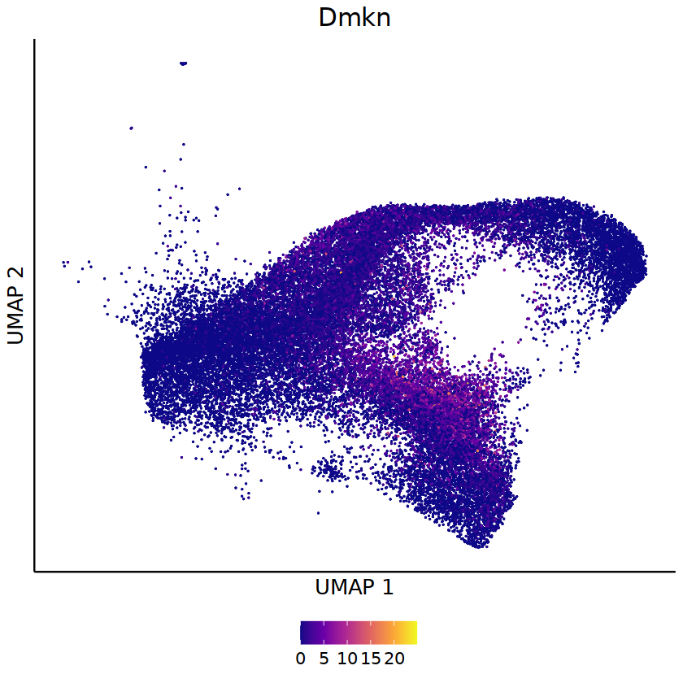

```r
feature_scatter = dimplot(embedding = umap,annot = t(exprs),color_by = example_gene,label  = FALSE,size = 0.1)+
scale_color_viridis_c(name = "",option = "plasma")+
theme(axis.text = element_blank(),    # Remove axis numbers (labels)
      axis.ticks = element_blank(),
      plot.title = element_text(hjust = 0.5),
      legend.position = "right")+
ggtitle(example_gene)+
xlab("UMAP 1")+ylab("UMAP 2")
feature_scatter
```

Obviously, this `Dmkn` gene shows higher expression in the bipotent profile no matter in monocyte or neutriphil.